# Problem set 3

Aakash Ahuja

04/02/2020

**Importing Data and Libraries**

```r
#install.packages('NHANES')
library(purrr)
library(dplyr)
```

```r
library(NHANES)
library(ggplot2)
library(MASS)
library(broom)
library(tidyr)
nhanes_data<- cbind.data.frame(BPSysAve=NHANES$BPSysAve, Age=NHANES$Age,Weight=NHANES$Weight, Height=NHANES$Height, Gender=NHANES$Gender)

#Removing Missing Data:Left with 8487 observations which is more than enough to draw inferences
nhanes_data_new<-na.omit(nhanes_data)
```

**Section 1: Relationship between Average Systolic Blood Pressure and Age**

I took the mean of average systolic blood pressure for each age and plotted it against each age.

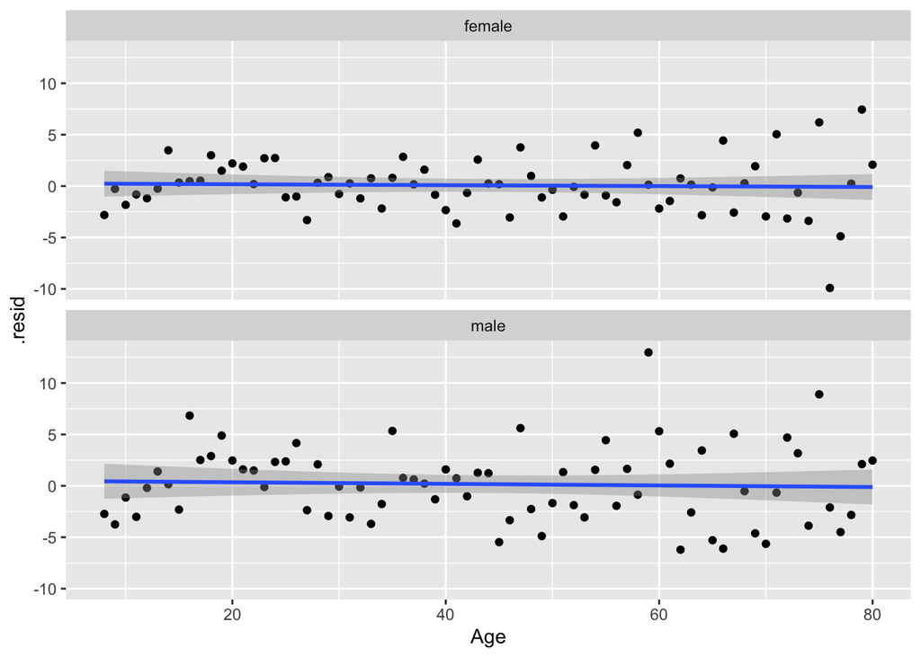

```r
#calculating mean average systolic blood pressure by age and gender
Mean_age_group_bygender<-as.data.frame(nhanes_data_new %>%
  group_by(Age,Gender) %>%
  summarise(BPSysAve=mean(BPSysAve)))

#Fitting model
Age_fit_1<-Mean_age_group_bygender %>%
  nest(-Gender) %>%
  mutate(Gender = Gender,
         fit = map(data, ~ loess(BPSysAve ~ Age, data = .)),
         results = map(fit, augment)) %>%
         unnest(results)

#Plotting Residuals against our x variable
ggplot(Age_fit_1, aes(x = Age, y = .resid)) + geom_point()+ geom_smooth(method ="lm")+ facet_wrap(~Gender, ncol = 1)
```

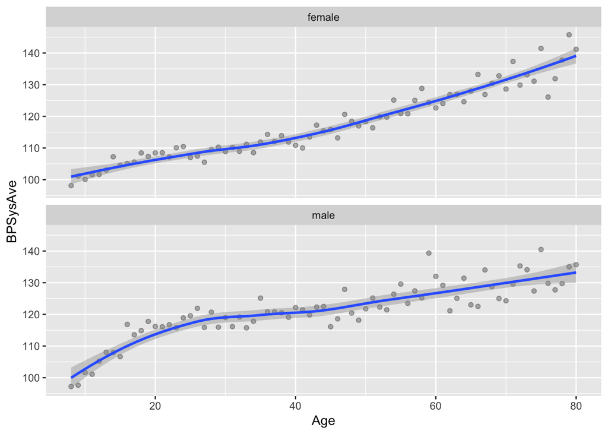

```r
#Plotting mean average systolic blood pressure for each age group by gender
ggplot(data = Mean_age_group_bygender, aes(x=Age,y=BPSysAve))+
  geom_point(alpha=0.3)+
  geom_smooth(method = 'loess')+
  facet_wrap(~Gender,ncol = 1)
```

2. Here, I took the mean of average systolic blood pressure for each age and plotted it against each age.There’s a clear trend to be seen. As the age increases, the average systolic blood pressure also increases. We also know that the systolic blood pressure should be in the range of 90-120. But after age 50 the average systolic blood pressure for people is above 120. So people should be careful about this and take extra care of their health after they cross 50.

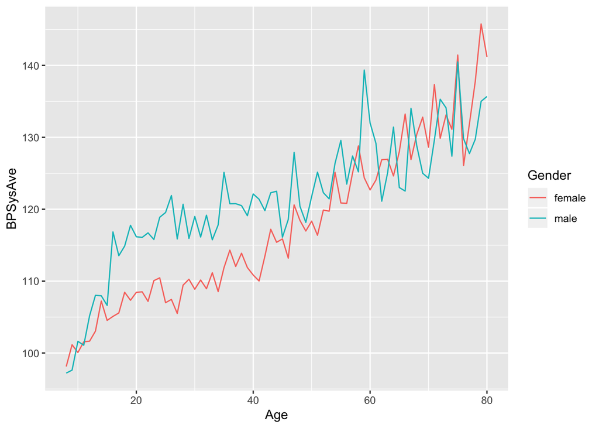

```r
ggplot(data = Mean_age_group_bygender, aes(x=Age,y=BPSysAve,color=Gender)) +
  geom_line()
```

**Section 2: Relationship between Average Systolic Blood Pressure and Height**

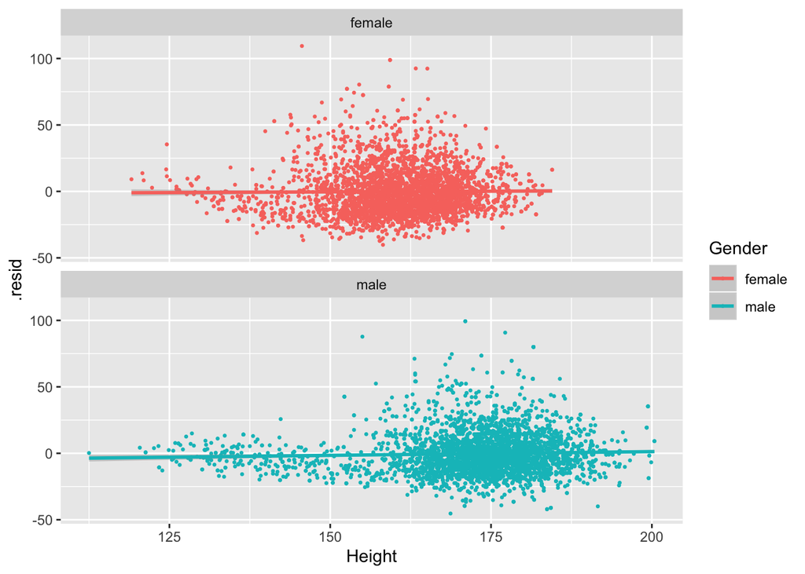

```r
library(purrr)
#Fitting model
Height_fit_1<-nhanes_data_new %>%
  nest(-Gender) %>%
  mutate(Gender = Gender,
         fit = map(data, ~ loess(BPSysAve ~ Height, data = .)),
         results = map(fit, augment)) %>%
         unnest(results)

#Plotting Residuals against our Height
ggplot(Height_fit_1, aes(x = Height, y = .resid, color=Gender)) + geom_point(size=0.5)+ geom_smooth(method ="lm")+ facet_wrap(~Gender, ncol = 1)
```

1. I fit a loess model over here. This model gives the best residual plots. There doesn’t seem to be any clear and obvious trend in the residuals plots for this variable with the trend line set around 0. This validates the independence of errors and homoskedasticity assumption.

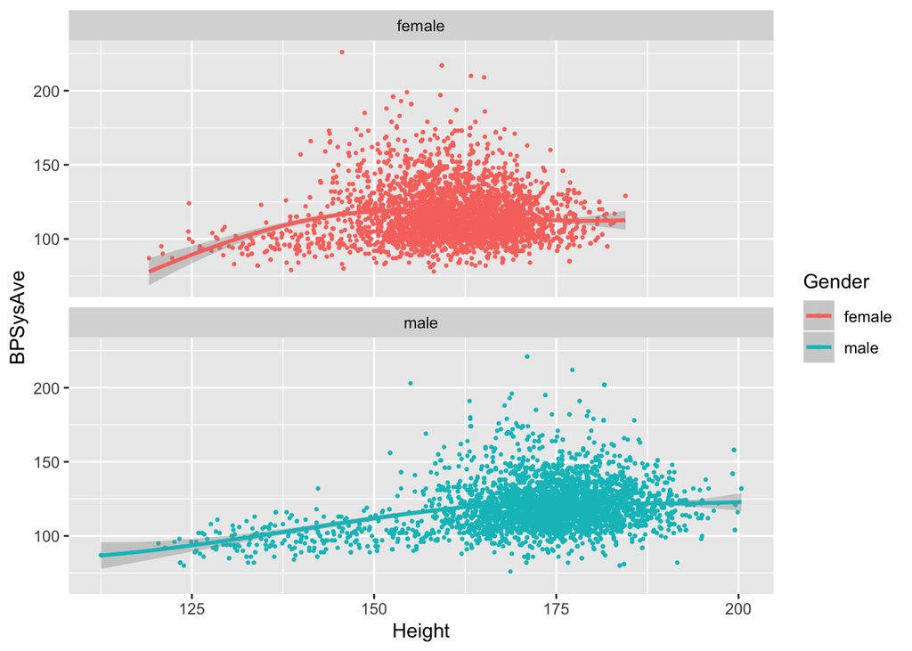

```r
ggplot(nhanes_data_new, aes(x = Height, y = BPSysAve, color=Gender)) + geom_point(size=0.5)+ geom_smooth(method ="loess")+ facet_wrap(~Gender, ncol = 1)
```

There’s no interesting trend visible through this graph. As the height increases in the growth spurt of a child till he reaches approx 150cm, the Average systolic blood pressure increases from 90 to 110. After that it plateaus showing that height really doesn’t affect average systolic blood pressure

**Section 3: Relationship between Average Systolic Blood Pressure and Weight**

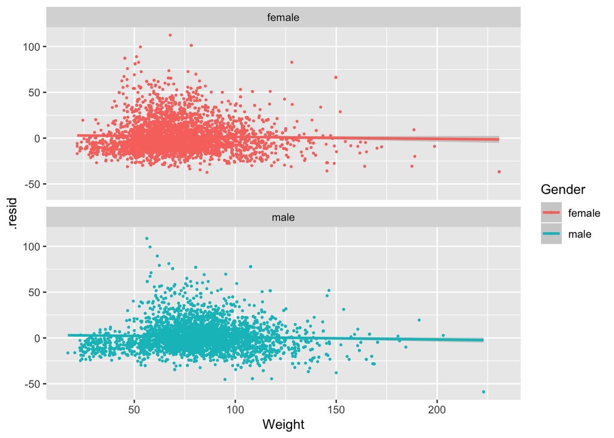

```r
library(purrr)
#Fitting model
Weight_fit_1<-nhanes_data_new %>%
  nest(-Gender) %>%
  mutate(Gender = Gender,
         fit = map(data, ~ rlm(BPSysAve ~ Weight, data = .)),
         results = map(fit, augment)) %>%
         unnest(results)

#Plotting Residuals against our Weight
ggplot(Weight_fit_1, aes(x = Weight, y = .resid, color=Gender)) + geom_point(size=0.5)+ geom_smooth(method ="lm")+ facet_wrap(~Gender, ncol = 1)
```

Here we analysed the relationship between Average systolic blood pressure and weight. I fit a robust linear model on the data. As we can see from the residual plot, there doesn’t seem to be any clear and obvious trend in the residual vs weight plot. This validates the independence of error and homoskedasticity assumption. Also the residual trend line stays around 0 all throughout the data which is a good sign.

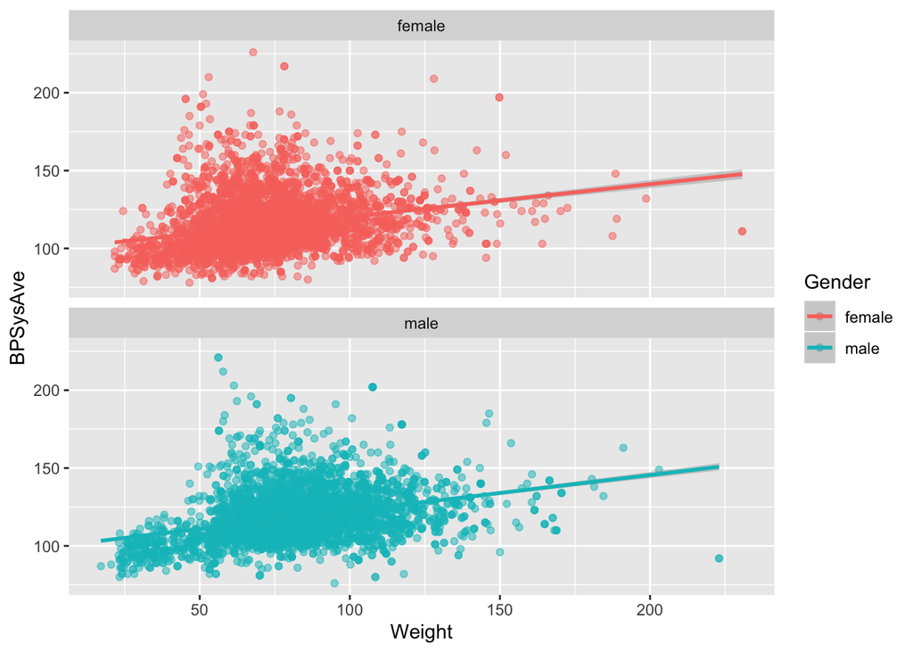

```r
#Plotting Weight against Average Systolic Blood Pressure
ggplot(data = nhanes_data_new, aes(x=Weight, y=BPSysAve, color=Gender))+geom_point(alpha=0.5)+
geom_smooth(method = 'rlm')+ facet_wrap(~Gender, ncol = 1)
```

From the plot, we can see that as weight increases, average systolic blood pressure is also increasing(clear & obvious). The rate of increase of average systolic blood pressure with weight is pretty much the same for female and male. Overall, the average systolic blood pressure is also approximately same for male and female.